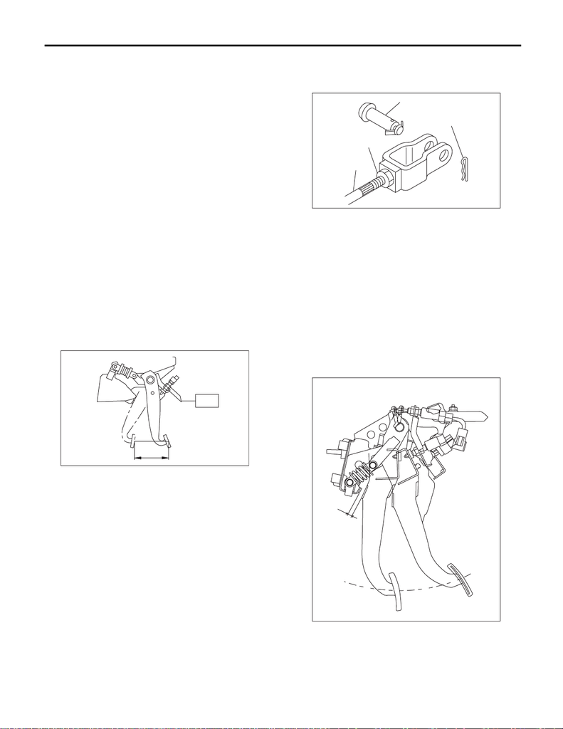

CL-35

Clutch Switch

CLUTCH SYSTEM

11.Clutch Switch

A: REMOVAL

1) Disconnect the ground cable from battery. <Ref.

to NT-5, BATTERY, NOTE, Note.>

NOTE:

For models other than STI model, disconnect the

ground terminal from battery sensor.

2) Remove the instrument panel lower cover.

3) Disconnect the connector from the clutch switch.

4) Remove the clutch switches.

B: INSTALLATION

1. CLUTCH SWITCH (CRUISE CONTROL)

1) Move the clevis pin of push rod to left and right,

retain it at the position where it moves smoothly,

and measure the clutch pedal stroke.

Clutch pedal full stroke A:

STI model

130 — 135 mm (5.12 — 5.31 in)

Except for STI model

135 — 140 mm (5.31 — 5.51 in)

Tightening torque:

T: 8 N·m (0.8 kgf-m, 5.9 ft-lb)

2) If the clutch pedal stroke is out of specification,

adjust the stroke. <Ref. to CL-33, ADJUSTMENT,

Clutch Pedal.>

3) Connect the clutch switch connector.

2. CLUTCH START SWITCH

1) Remove the snap pin and clevis pin connecting

the clutch pedal and operating rod.

2) Install the clutch start switch so that the clutch

switch turns on when the clearance between clutch

pedal stopper and clutch pedal is within the specifi-

cation described below.

Clearance A:

6.3 — 8.6 mm (0.25 — 0.34 in)

Tightening torque:

8 N·m (0.8 kgf-m, 5.9 ft-lb)

CL-00225

T

A

(A) Clevis pin

(B) Snap pin

(C) Push rod

(D) Lock nut

CL-00042

(A)

(B)

(C)

(D)

CL-00894

(A)

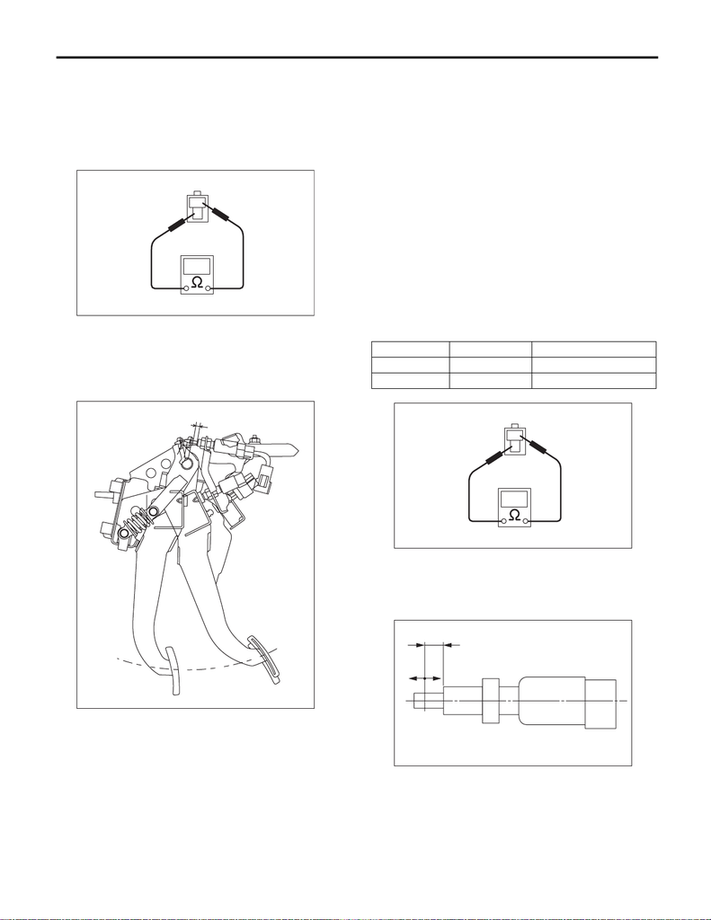

CL-36

Clutch Switch

CLUTCH SYSTEM

NOTE:

• Using a plate of the same thickness for the clear-

ance facilitates the adjustment operation.

• Using the Subaru Select Monitor or a tester,

check the position where the switch turns on.

Check the following figure for the terminal layout of

the harness connector.

• When performing adjustment by the clearance

between clutch start switch and clutch pedal plate,

perform installation according to the following gap.

Clearance B:

8.6 — 9.0 mm (0.34 — 0.35 in)

3) Connect the clutch start switch connector.

4) Make sure that engine does not start with clutch

pedal not depressed.

5) Make sure that engine starts with clutch pedal

depressed.

C: INSPECTION

1. CLUTCH START SWITCH

1) Perform the following inspections. If the clutch

start switch does not operate normally, adjust the

switch, and check it again. <Ref. to CL-37, AD-

JUSTMENT, Clutch Switch.>

• Make sure that engine does not start with clutch

pedal not depressed.

• Make sure that engine starts with clutch pedal

fully depressed.

2) When the clutch start switch does not operate

normally even if it is adjusted, check the clutch start

switch for continuity.

(1) Remove the clutch start switch. <Ref. to CL-

35, REMOVAL, Clutch Switch.>

(2) Measure the resistance between terminal 1

and 2 of the switch. If the resistance is not at the

standard value, replace the switch.

(3) Check that the switch is turned on and off in

dimension L.

Dimension L:

9 — 10 mm (0.35 — 0.39 in)

CL-00102

1

2

(B)

CL-00891

Condition Terminal No. Specified resistance

ON No. 1 — No. 2 Less than 1 Ω

OFF No. 1 — No. 2 1 MΩ or more

(A) ON

(B) OFF

CL-00102

1

2

CL-00799

L

(B) (A)

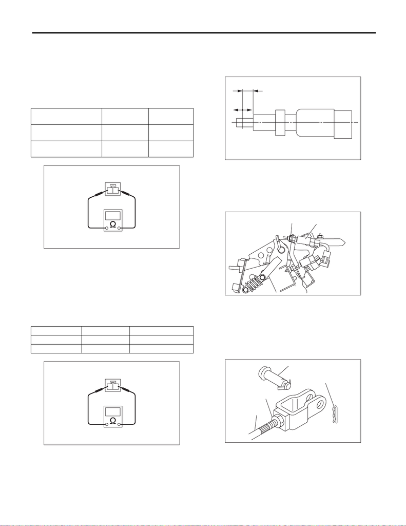

CL-37

Clutch Switch

CLUTCH SYSTEM

2. CLUTCH SWITCH

1) Check the clutch switch for continuity.

(1) Disconnect the connector of clutch switch.

(2) Measure the resistance between terminal 1

and 2 of the switch. If the resistance is not within

the specification, check the clutch stroke and in-

stallation condition, and check the clutch switch

again.

2) When the clutch switch does not operate nor-

mally even if the clutch stroke and installation con-

dition are normal, check the clutch switch for

continuity.

(1) Remove the clutch switches. <Ref. to CL-

35, REMOVAL, Clutch Switch.>

(2) Measure the resistance between terminal 1

and 2 of the switch. If the resistance is not at the

standard value, replace the switch.

(3) Check that the switch is turned on and off in

Dimension L.

Dimension L:

5 — 6.5 mm (0.2 — 0.26 in)

D: ADJUSTMENT

1) Loosen the lock nut of the clutch start switch.

2) Disconnect the harness connector of the clutch

start switch.

3) Remove the snap pin and clevis pin connecting

the clutch pedal and operating rod.

Condition Terminal No.

Specified

resistance

When clutch pedal is

depressed

No. 1 — No. 2 1 MΩ or more

When the clutch pedal is

not depressed

No. 1 — No. 2 Less than 1 Ω

Condition Terminal No. Specified resistance

ON No. 1 — No. 2 Less than 1 Ω

OFF No. 1 — No. 2 1 MΩ or more

CL-00084

21

CL-00084

21

(A) ON

(B) OFF

(A) Lock nut

(B) Clutch start switch

(A) Clevis pin

(B) Snap pin

(C) Push rod

(D) Lock nut

CL-00799

L

(B) (A)

CL-00899

(A)

(B)

CL-00042

(A)

(B)

(C)

(D)

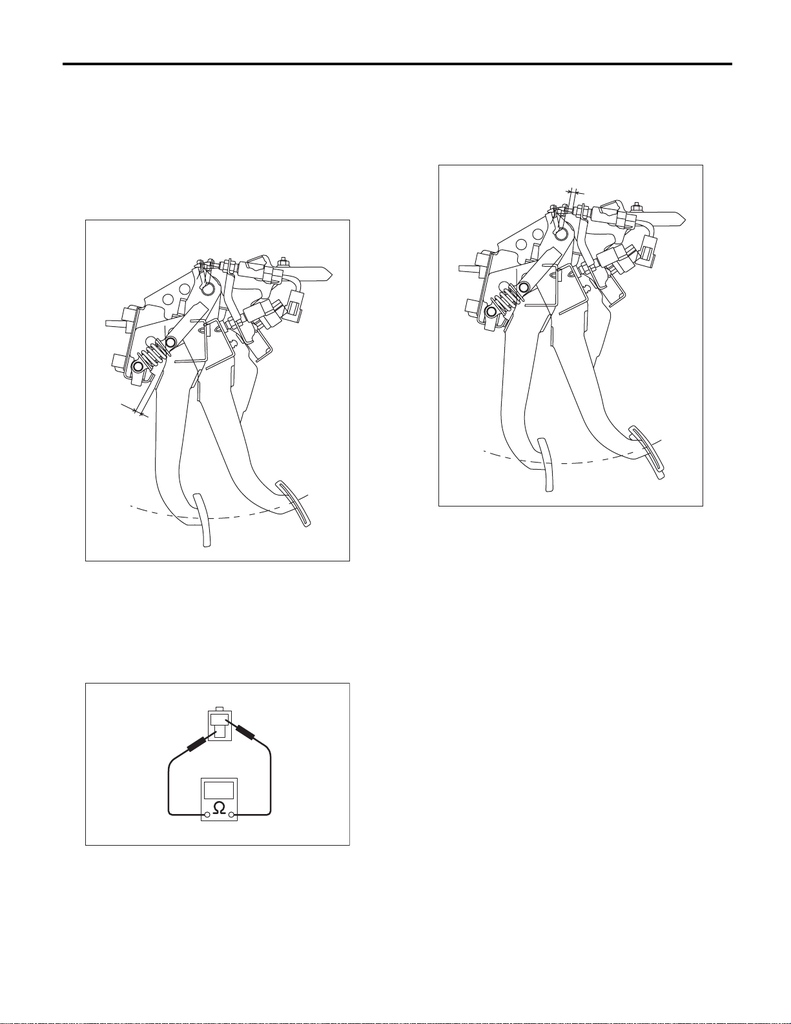

CL-38

Clutch Switch

CLUTCH SYSTEM

4) Adjust the clutch start switch so that the switch

turns on when the clearance between clutch pedal

stopper and clutch pedal is within the specification

described below, and then tighten the lock nut.

Clearance A:

6.3 — 8.6 mm (0.25 — 0.34 in)

Tightening torque:

8 N·m (0.8 kgf-m, 5.9 ft-lb)

NOTE:

• Using a plate of the same thickness for the clear-

ance facilitates the adjustment operation.

• Using the Subaru Select Monitor or a tester,

check the position where the switch turns on.

Check the following figure for the terminal layout of

the harness connector.

• When performing adjustment by the clearance

between clutch start switch and clutch pedal plate,

perform installation according to the following gap.

Clearance B:

8.6 — 9.0 mm (0.34 — 0.35 in)

5) Connect the clutch start switch connector.

CL-00894

(A)

CL-00102

1

2

(B)

CL-00891